# 斯特普鲁实验样本数据探索

email：waynewqh@foxmail.com

## 实验背景

**斯特鲁普效应**（英语：Stroop Effect），又译Stroop效应、司楚卜效应、史楚普效应，是由美国的实验心理学家约翰莱德利斯特鲁普于1935年最先以英语提出的效应，因此以他的名字命名。

这个效应展示了人们对事物的认知过程已是一个自动化的历程。当有一个新的刺激出现时，如果它的特征和原先的刺激相似或符合一致，便会加速人们的认知；反之，若新的刺激特征与原先的刺激不相同，则会干扰人们的认知，使人们的所需的反应时间变长。

在心理学中，斯特鲁普效应是干扰对处理任务时反应时间的论证。例如，将一个颜色的名称（例如“蓝色”、“绿色”、“红色”、“橘色”）以不是它所代表的颜色显示时（例如文字“红色”以绿色油墨显示，而非红色油墨；或是文字“橘色”是以蓝色油墨显示而非橘色油墨），对比于文字及其颜色一致时，前者必须花较长的时间来辨识文字的颜色，而且辨识过程也更容易出错。斯特鲁普效应也被用来创造一个心理学上著名的实验，即“斯特鲁普实验”（Stroop Test），或称为“斯特鲁普颜色与文字实验”（Stroop Color and Word Test，简称SCWT）。

——摘录自维基百科

## 实验说明

在本次斯特鲁普实验中，受试者将会接受两个任务。第一个任务是给受试者看一张卡片，卡片里有一组与其打印颜色相匹配的颜色词汇，如’RED‘、’BLUE‘、’BROWN‘等，受试者需要正确朗读完所有文字的打印颜色，并且记录其时间。第二个任务是给受试者看另一张卡片，卡片里有与任务一同样数量的一组颜色词汇，但其打印颜色与此词汇可能并不匹配，如’WHITE‘、’YELLOW‘、’GREEN‘，受试者需要正确朗读完所有文字的打印颜色（在此例子就需要受试者正确朗读出green、pink、orange），并且记录其时间。

任务一示例图：

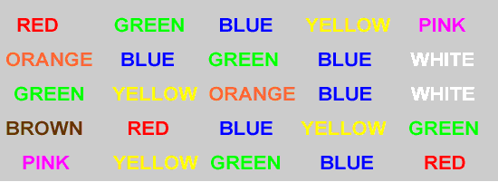

任务二示例图：

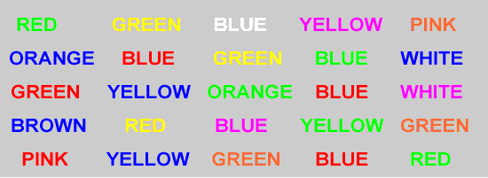

（示例图素材见参考栏目）

## 实验数据

| 序号 | Congruent() | Incongruent() | Difference() |
| --- | --- | --- | --- |
| 1 | 12.079 | 19.278 | 7.199 |
| 2 | 16.791 | 18.741 | 1.95 |
| 3 | 9.564 | 21.214 | 11.65 |
| 4 | 8.63 | 15.687 | 7.057 |
| 5 | 14.669 | 22.803 | 8.134 |
| 6 | 12.238 | 20.878 | 8.64 |
| 7 | 14.692 | 24.572 | 9.88 |
| 8 | 8.987 | 17.394 | 8.407 |
| 9 | 9.401 | 20.762 | 11.361 |
| 10 | 14.48 | 26.282 | 11.802 |
| 11 | 22.328 | 24.524 | 2.196 |
| 12 | 15.298 | 18.644 | 3.346 |
| 13 | 15.073 | 17.51 | 2.437 |
| 14 | 16.929 | 20.33 | 3.401 |
| 15 | 18.2 | 35.255 | 17.055 |
| 16 | 12.13 | 22.158 | 10.028 |
| 17 | 18.495 | 25.139 | 6.644 |
| 18 | 10.639 | 20.429 | 9.79 |
| 19 | 11.344 | 17.425 | 6.081 |
| 20 | 12.369 | 34.288 | 21.919 |
| 21 | 12.944 | 23.894 | 10.95 |
| 22 | 14.233 | 17.96 | 3.727 |
| 23 | 19.71 | 22.058 | 2.348 |
| 24 | 16.004 | 21.157 | 5.153 |

本次实验样本取自[stroopdata](https://s3.cn-north-1.amazonaws.com.cn/static-documents/nd002/stroopdata.csv)。

## 数据可视化

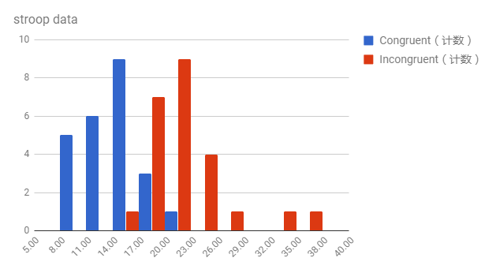

## 实验假设

我们希望本次检验能对比斯特鲁普效应在处理任务时对受试者的反应时间产生什么影响。因此在本次实验里的自变量是文字与打印颜色的一致与否，而因变量则是完成任务的时间。

- 自变量：文字与打印颜色是否一致
- 因变量：受试者完成任务的时间

## 假设检验

在t检验中我们希望通过样本任务二和任务一的差列的均值，来推断总体均值是否符合我们的零假设。

## 总结

在本次检验中，我们证实了斯特鲁普效应的存在，在本次的实验样本中即是受试者会因为文字与打印颜色的不一致的干扰而导致处理信息时反应时间增加。此效应可能说明了我们的大脑在接收处理信息时，根据信息的不同类型可能会有反应上的差别。在此实验中我们可以得出另一个可能的结论，也就是大脑在处理信息时会优先处理文字意义，然后才是处理颜色信息。

## 参考

[维基百科：斯特鲁普效应](https://zh.wikipedia.org/wiki/%E6%96%AF%E7%89%B9%E9%B2%81%E6%99%AE%E6%95%88%E5%BA%94)

[斯特鲁普实验样本数据](https://s3.cn-north-1.amazonaws.com.cn/static-documents/nd002/stroopdata.csv)

[斯特鲁普实验参考素材](https://faculty.washington.edu/chudler/java/ready.html)